# FML_Assignment_2

Peter

2024-02-25

## Problem Statement

Universal Bank aims to expand its asset customer base borrowers by converting its liability customers depositors to personal loan customers. A previous campaign for liability customers showed a 9% conversion rate, encouraging the retail marketing department to design smarter campaigns using k-NN to predict acceptance of loan offers.

The UniversalBank.csv file has data on 5000 customers, their demographic info, relationship with the bank, and response to the last personal loan campaign. Only 9.6% of the customers accepted the loan. Partition the data into 60% training and 40% validation sets.

```r
#Loading the libraries needed
library(caret)
library(class)
library(readr)
library(dplyr)
library(e1071)
```

```r
#In puting the data and checking the data count using dim function.
UniversalBank <- read.csv("./UniversalBank.csv")
dim(UniversalBank)
```

```
## [1] 5000   14
```

```r
t(t(names(UniversalBank))) # The t function creates a transpose of the data frame
```

```
##       [,1]
##  [1,] "ID"
##  [2,] "Age"
##  [3,] "Experience"
##  [4,] "Income"
##  [5,] "ZIP.Code"
##  [6,] "Family"
##  [7,] "CCAvg"
##  [8,] "Education"
##  [9,] "Mortgage"
## [10,] "Personal.Loan"
## [11,] "Securities.Account"
## [12,] "CD.Account"
## [13,] "Online"
## [14,] "CreditCard"
```

Drop ID and ZIP

```r
#Deleting columns ID and ZIP code, which do not add any insight.
UniversalBank <- UniversalBank[,-c(1,5)]
head(UniversalBank, 3)
```

```
##   Age Experience Income Family CCAvg Education Mortgage Personal.Loan
## 1  25          1     49      4   1.6         1        0             0
## 2  45         19     34      3   1.5         1        0             0
## 3  39         15     11      1   1.0         1        0             0
##   Securities.Account CD.Account Online CreditCard
## 1                  1          0      0          0
## 2                  1          0      0          0
## 3                  0          0      0          0
```

Converting categorical variables into dummy variables

```r
# Converting education as factor
UniversalBank$Education <- as.factor(UniversalBank$Education)
levels(UniversalBank$Education)
```

```
## [1] "1" "2" "3"
```

```r
# Converting Education to Dummy Variables
EDU <- dummyVars(~., data = UniversalBank) #creating the dummy groups
UniversalBankNew <- as.data.frame(predict(EDU,UniversalBank))
head(UniversalBankNew, 3)
```

```
##   Age Experience Income Family CCAvg Education.1 Education.2 Education.3
## 1  25          1     49      4   1.6           1           0           0
## 2  45         19     34      3   1.5           1           0           0
## 3  39         15     11      1   1.0           1           0           0
##   Mortgage Personal.Loan Securities.Account CD.Account Online CreditCard
## 1        0             0                  1          0      0          0
## 2        0             0                  1          0      0          0
## 3        0             0                  0          0      0          0
```

```r
# Running this code to make sure we get the same sample even if we rerun codes
set.seed(1)
train60 <- sample(row.names(UniversalBankNew),0.6*dim(UniversalBankNew)[1])
valid40 <- setdiff(row.names(UniversalBankNew), train60)
train60.df <- UniversalBankNew[train60,]
valid40.df <- UniversalBankNew[valid40,]
t(t(names(train60.df)))
```

```
##       [,1]
##  [1,] "Age"
##  [2,] "Experience"
##  [3,] "Income"
##  [4,] "Family"
##  [5,] "CCAvg"
##  [6,] "Education.1"
##  [7,] "Education.2"
##  [8,] "Education.3"
##  [9,] "Mortgage"
## [10,] "Personal.Loan"
## [11,] "Securities.Account"
## [12,] "CD.Account"
## [13,] "Online"
## [14,] "CreditCard"
```

```r
# Splitting the data into two sets of 60% and 40% of Training and Validation respectively.
library(caTools)
set.seed(1)
x <- sample.split(UniversalBankNew, SplitRatio = 0.6)
trainx <- subset(UniversalBankNew, x == TRUE)
valix <- subset(UniversalBankNew, x == FALSE)

# Dim function to check the data size.
dim(trainx)
```

```
## [1] 2858   14
```

```r
dim(valix)
```

```
## [1] 2142   14
```

Normalizing the data

```r
train60norm <- train60.df[,-10] # Removing Personal.Loan which is the 10 column.
valid40norm <- valid40.df[,-10]

norm.values <- preProcess(train60.df[, -10], method=c("center", "scale"))
train60norm <- predict(norm.values, train60.df[, -10])
valid40norm <- predict(norm.values, valid40.df[, -10])
```

### Inquiry 1

From the problem 1. Age = 40, Experience = 10, Income = 84, Family = 2, CCAvg = 2, Education_1 = 0, Education_2 = 1, Education_3 = 0, Mortgage = 0, Securities Account = 0, CD Account = 0, Online = 1, and Credit Card = 1. Perform a k-NN classification with all predictors except ID and ZIP code using k = 1.

```r
# We have converted categorical variables to dummy variables
Customer <- data.frame(Age = 40, # Creating a variable using the data given in the problem
                           Experience = 10,
                           Income = 84,
                           Family = 2,
                           CCAvg = 2,
                           Education.1 = 0,
                           Education.2 = 1,
                           Education.3 = 0,
                           Mortgage = 0,
                           Securities.Account = 0,
                           CD.Account = 0,
                           Online = 1,
                           CreditCard = 1)

# Normalize the customer data
Customernorm <- Customer
Customernorm <- predict(norm.values, Customernorm)
```

```r
# Prediction using kNN
predictionfrocustom <- class::knn(train = train60norm,
                       test = Customernorm,
                       cl = train60.df$Personal.Loan, k = 1)
predictionfrocustom
```

```
## [1] 0
## Levels: 0 1
```

From the Problem 2. What is a choice of k that balances between over fitting and ignoring the predictor information?

Inference - K can be selected as 3

```r
# Calculating the accuracy level for the values of k
# Setting the range of k values to take into consideration

Emod <- data.frame(k = seq(1, 15, 1), overallaccuracy = rep(0, 15))
for(i in 1:20) {
  knn.pred1 <- class::knn(train = train60norm,
                         test = valid40norm,
                         cl = train60.df$Personal.Loan, k = i)
  Emod[i, 2] <- confusionMatrix(knn.pred1, as.factor(valid40.df$Personal.Loan),positive = "1")$overall[1]
}

which(Emod[,2] == max(Emod[,2]))
```

```
## [1] 3
```

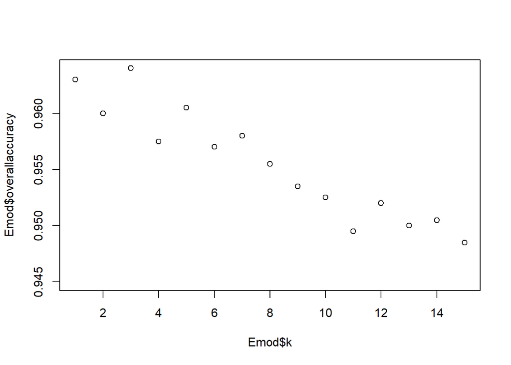

```r
plot(Emod$k,Emod$overallaccuracy)
```

*** From the problem 3. Show the confusion matrix for the validation data that results from using the best k.

```r
prediction <- class::knn(train = train60norm,
                        test = valid40norm,
                        cl = train60.df$Personal.Loan, k = 3)

confusionMatrix(prediction,as.factor(valid40.df$Personal.Loan))
```

```
## Confusion Matrix and Statistics
##
##           Reference
## Prediction    0    1
##          0 1786   63
##          1    9  142
##
##                Accuracy : 0.964
##                  95% CI : (0.9549, 0.9717)
##     No Information Rate : 0.8975
##     P-Value [Acc > NIR] : < 2.2e-16
##
##                   Kappa : 0.7785
##
##  Mcnemar's Test P-Value : 4.208e-10
##
##             Sensitivity : 0.9950
##             Specificity : 0.6927
##          Pos Pred Value : 0.9659
##          Neg Pred Value : 0.9404
##              Prevalence : 0.8975
##          Detection Rate : 0.8930
##    Detection Prevalence : 0.9245
##       Balanced Accuracy : 0.8438
##
##        'Positive' Class : 0
##
```

From the problem 4. Consider the following customer: Age = 40, Experience = 10, Income = 84, Family = 2, CCAvg = 2, Education_1 = 0, Education_2 = 1, Education_3 = 0, Mortgage = 0, Securities Account = 0, CD Account = 0, Online = 1 and Credit Card = 1. Classify the customer using the best k.

```r
# Classifying the customer using the best K, K result taken from query 2 after finding the K ie 3.
Customer2 = data.frame(Age = 40,
                           Experience = 10,
                           Income = 84,
                           Family = 2,
                           CCAvg = 2,
                           Education.1 = 0,
                           Education.2 = 1,
                           Education.3 = 0,
                           Mortgage = 0,
                           Securities.Account = 0,
                           CD.Account = 0,
                           Online = 1,
                           CreditCard = 1)

Predict3 <- class::knn(train = train60norm,
                         test = Customer2,
                         cl = train60.df$Personal.Loan, k = 3)
Predict3
```

```
## [1] 1
## Levels: 0 1
```

```r
#The customer can be classified as approved for personal loan.
```

From the problem 5.Re partition the data, this time into training, validation, and test sets (50% : 30% : 20%). Apply the k-NN method with the k chosen above. Compare the confusion matrix of the test set with that of the training and validation sets. Comment on the differences and their reason.

Inference - After partitioning the data into training, validation, and test sets, we need to apply the k-NN algorithm to the test set. Then, we should compare the results of the confusion matrix of the test set with those obtained from the training and validation sets. It is important to note that differences in the confusion matrices of the test set compared to the training and validation sets can occur due to several reasons, such as overfitting, data variability, sample size, and randomness.

```r
set.seed(2)
# Removing 50% of the modified data
train.set2 = sample(row.names(UniversalBankNew),0.5*dim(UniversalBankNew)[1])

# Need to take 30% of the data from the remaining 50% for validation purposes.
valid.set2 = sample(setdiff(row.names(UniversalBankNew), train.set2), 0.3*dim(UniversalBankNew)[1])

# To proceed with the testing, please ensure that the remaining 20% of the modified data is reserved as Test Data
test.set2 = setdiff(row.names(UniversalBankNew),union(train.set2,valid.set2))

train.norm.df2 = UniversalBankNew[train.set2,]
valid.norm.df2 = UniversalBankNew[valid.set2,]
test.norm.df2 = UniversalBankNew[test.set2,]

# Transposing the data
t(t(names(train.norm.df2)))
```

```
##       [,1]
##  [1,] "Age"
##  [2,] "Experience"
##  [3,] "Income"
##  [4,] "Family"
##  [5,] "CCAvg"
##  [6,] "Education.1"
##  [7,] "Education.2"
##  [8,] "Education.3"
##  [9,] "Mortgage"
## [10,] "Personal.Loan"
## [11,] "Securities.Account"
## [12,] "CD.Account"
## [13,] "Online"
## [14,] "CreditCard"
```

```r
# Applying k-NN method with the chosen K.

trainknn2 = knn(train = train.norm.df2[,-8], test = train.norm.df2[,-8], cl = train.norm.df2[,8], k=3)

validknn2 = knn(train = train.norm.df2[,-8], test = valid.norm.df2[,-8], cl = train.norm.df2[,8], k=3)

testknn2 = knn(train = train.norm.df2[,-8], test = test.norm.df2[,-8], cl = train.norm.df2[,8], k=3)
```